# Mes astuces préférées pour travailler avec ggplot dans un document RMarkdown

Benjamin Louis

2020-05-21

R markdown et `ggplot2` ont selon moi un avantage commun essentiel : leurs rendus sont hautement personnalisables ! Cet avantage tourne vite à l’inconvénient lorsque l’on débute : il existe tellement d’options qu’il est parfois fastidieux de savoir lesquelles utilisées et comment les combiner. Les configurations qui m’ont demandé le plus de temps sont celles concernant la taille des graphiques et la taille relative des éléments des graphques (textes, légendes, …). Dans cet article, je vous partage quelques astuces qui me permettent d’arriver à mes objectifs et ceux de mes clients.

**Pré-requis**

1. Dans cette article je pars du principe que vous avez déjà créer un graphique avec `ggplot2` et que vous avez essayer de le personnaliser. Si ça n’est pas le cas, vous pouvez commencer par consulter [ce livre](https://ggplot2-book.org/) disponible gratuitement en ligne. Ici on partira du graphique suivant :

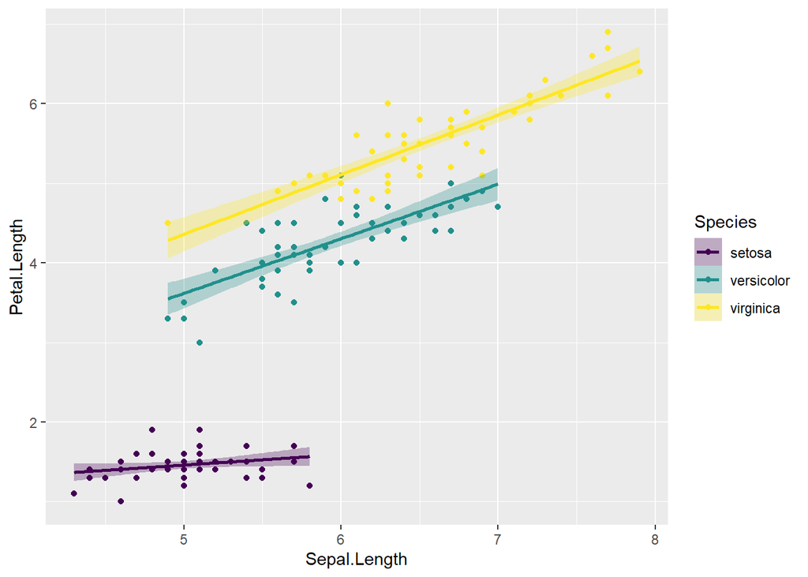

```r
library(ggplot2)
p <- ggplot(iris, aes(x = Sepal.Length, y = Petal.Length, color = Species, fill = Species)) +
  geom_point() +
  geom_smooth(method = "lm", formula = "y ~ x", alpha = 0.3) +
  scale_color_viridis_d() +
  scale_fill_viridis_d()
p
```

2. De même, vous êtes familier avec les documents R Markdown et vous savez ce qu’est un *chunk*. Dans le cas contraire, commencez [ici](https://bookdown.org/yihui/rmarkdown/)

# Créer son propre thème `ggplot2`

Le thème `ggplot2` correspond à l’apparence du graphique. Il est possible de changer des éléments un par un via la fonction [`theme()`](https://ggplot2.tidyverse.org/reference/theme.html) mais il existe également des thèmes pré-configurés. Par défaut c’est `theme_gray()` qui est utilisé. Personnellement j’utilise plus souvent `theme_bw()` (pour black and white).

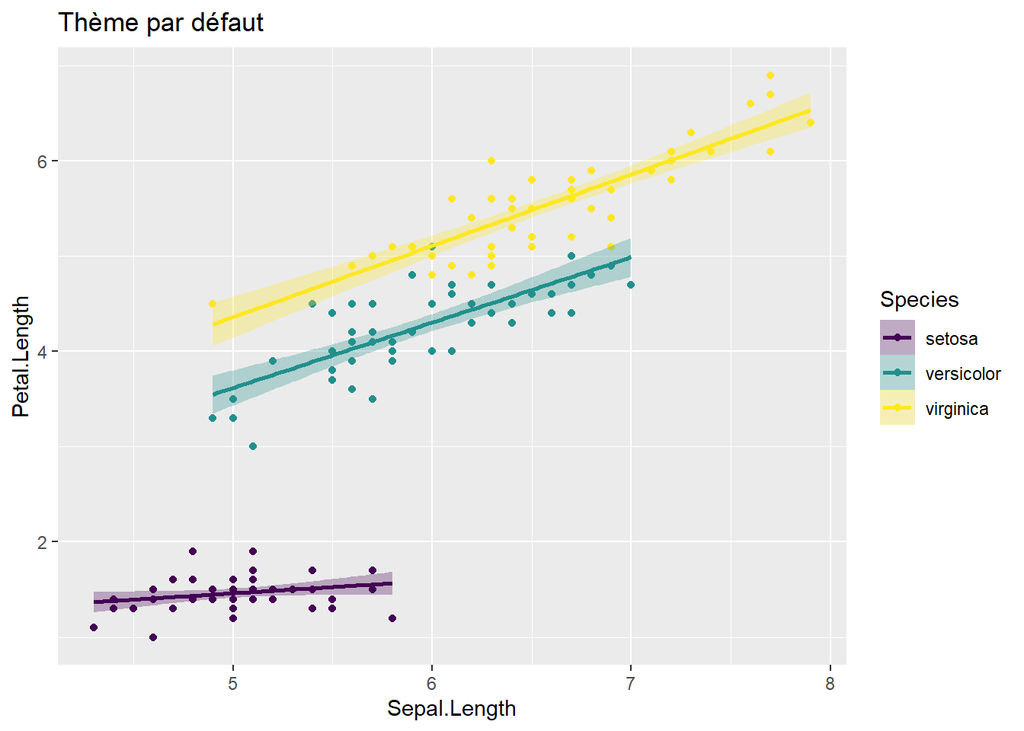

```r
p + labs(title = "Thème par défaut")
p + theme_bw() + labs(title = "Avec theme_bw()")
```

[output not shown]

Si vous appliquez souvent les mêmes changements via la fonction `theme()`, je vous recommande fortement de créer votre propre thème. Et un thème c’est avant tout une fonction. Voici un exemple de thème personnalisé :

```r
theme_ben <- function(base_size = 14) {
  theme_bw(base_size = base_size) %+replace%
    theme(
      # L'ensemble du graphique
      plot.title = element_text(size = rel(1), face = "bold", margin = margin(0,0,5,0), hjust = 0),
      # Zone où se situe l graphique
      panel.grid.minor = element_blank(),
      panel.border = element_blank(),
      # Les axes
      axis.title = element_text(size = rel(0.85), face = "bold"),
      axis.text = element_text(size = rel(0.70), face = "bold"),
      axis.line = element_line(color = "black", arrow = arrow(length = unit(0.3, "lines"), type = "closed")),
      # La légende
      legend.title = element_text(size = rel(0.85), face = "bold"),
      legend.text = element_text(size = rel(0.70), face = "bold"),
      legend.key = element_rect(fill = "transparent", colour = NA),
      legend.key.size = unit(1.5, "lines"),
      legend.background = element_rect(fill = "transparent", colour = NA),
      # Les étiquettes dans le cas d'un facetting
      strip.background = element_rect(fill = "#17252D", color = "#17252D"),
      strip.text = element_text(size = rel(0.85), face = "bold", color = "white", margin = margin(5,0,5,0))
    )
}
```

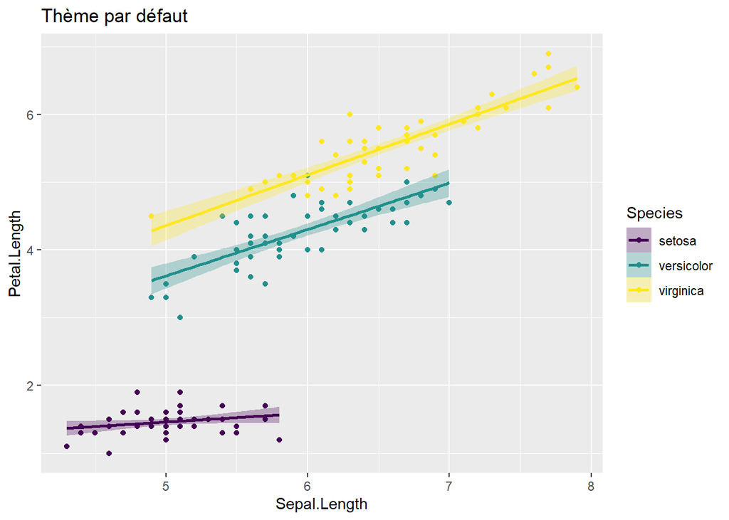

```r
p + labs(title = "Thème par défaut")
p + theme_ben() + labs(title = "Avec mon thème personnalisé")
```

[output not shown]